# Python for Trading

### Getting Started with Python for Algorithmic Trading

**Ran Aroussi**  
Founder @ [Tradologics](http://tradologics.com)  
[@aroussi](http://twitter.com/aroussi) | aroussi.com | github.com/ranaroussi

© 2020. All rights reserved.

# Agenda

- Python for Trading
- Trading strategy workflow
- Time-series analysis
- Backtesting
- Performance & risk metrics
- Strategy optimization

[figure not shown]

# About me

- Programming since I was 13 (33 years 😲) in various languages and disciplines
- Trading since 2013 (switched to automated trading in 2014)
- Created several popular Python libraries, with ~40K monthly installs
- Writing a book on "Python for Trading" for O'Reilly Media
- Founder of [Tradologics](https://tradologics.com) - a cloud platform for algorithmic traders

...

**Please follow me on [Twitter](http://twitter.com/aroussi) and [Github](https://github.com/ranaroussi) for ongoing Python and Trading stuff**

# Python for Trading

## Why Python?

- A very high-level language with clean and readable syntax
- Fast learning curve
- Object-oriented, multi-paradigm
- A rich standard library of modules
- One of the most used languages in IoT, **data science**, finance, and web development
- A strong open-source community

## "Hello World" in Python

```python
print("Hello, World!")
```

```
Hello, World!
```

```python
#include <iostream>
using namespace std;

int main()
{
    cout << "Hello, World!";
    return 0;
}
```

## Python for Algorithmic Trading

- Python's syntax is attractive for science, and particularly finance
- Fast learning curve
- Large selection of ML libraries
- Quick protopyting, fast enough execution
- Many libraries and tools available for trading ([Zipline](https://github.com/quantopian), [PyAlgoTrade](https://github.com/gbeced/pyalgotrade), [PyBacktest](https://github.com/ematvey/pybacktest), [QTPyLib](https://github.com/ranaroussi/qtpylib))
- **Pandas + Numpy**

## But wait? Isn't Python slow?

- Yes... It's about 200x slower compared to a language like C

**However...**

- Speed of execution is rarely a bottleneck. Speed of writing code, speed of making changes, speed of just playing with stuff to see what works, is more important than CPU time. [[1](https://www.pythonforengineers.com/why-is-python-so-popular-if-its-so-darn-slow/), [2](https://www.quora.com/Why-is-Python-so-popular-despite-being-so-slow)]
- You can speed Python by 100x-200x using either vectorization, parallelization, and by moving critical parts of the code to Cython

# Working with Time-series data

```python
import yfinance as yf

df = yf.download('TSLA', period="max", auto_adjust=True)
df.columns = map(str.lower, df.columns)
df.tail()
```

```
[*********************100%***********************]  1 of 1 completed
```

| Date | open | high | low | close | volume |
| --- | --- | --- | --- | --- | --- |
| 2019-11-25 | 344.320007 | 344.570007 | 334.459991 | 336.339996 | 12339500 |
| 2019-11-26 | 335.269989 | 335.500000 | 327.100006 | 328.920013 | 7947400 |
| 2019-11-27 | 331.119995 | 333.929993 | 328.570007 | 331.290009 | 5555600 |
| 2019-11-29 | 331.109985 | 331.260010 | 327.500000 | 329.940002 | 2465600 |
| 2019-12-02 | 329.399994 | 336.380005 | 328.690002 | 334.869995 | 6074500 |

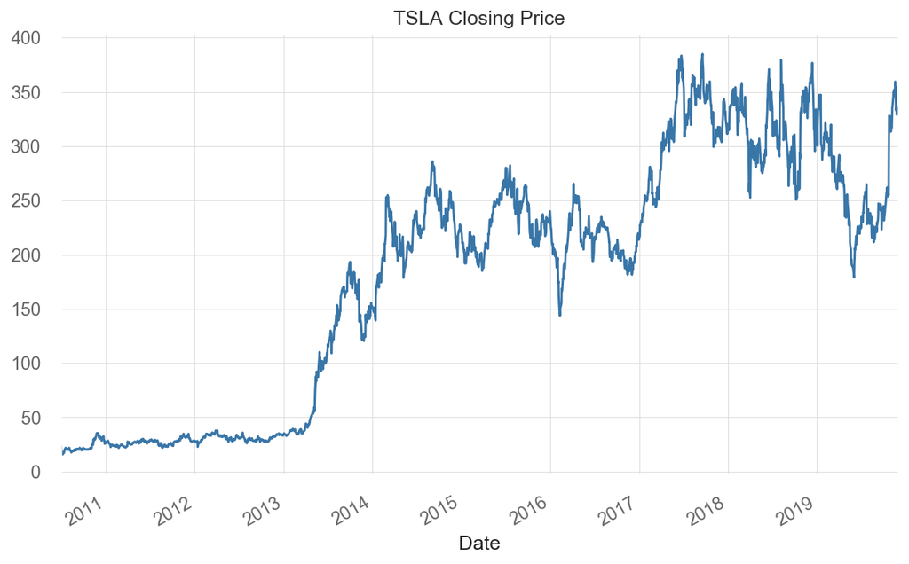

```python
df['close'].plot(title="TSLA Closing Price")
```

# Data Exploration

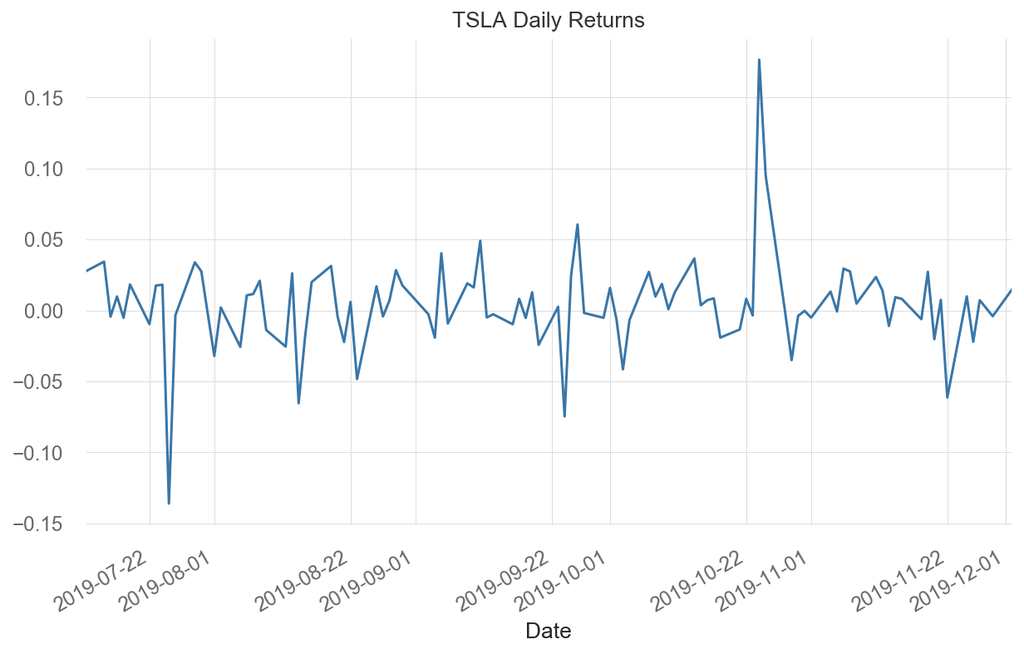

```python
df['returns'] = df['close'].pct_change()
df['returns'][-100:].plot(title="TSLA Daily Returns")
```

[output not shown]

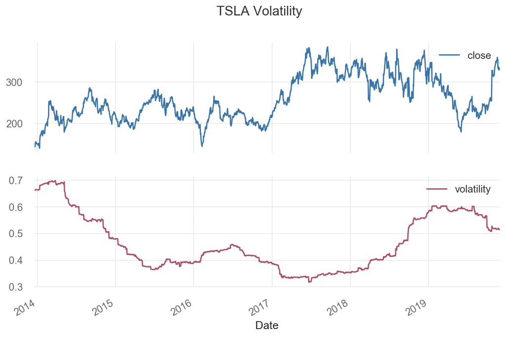

```python
df['log_ret'] = np.log(df['close'] / df['close'].shift(1))
df['volatility'] = df['log_ret'].rolling(window=252).std() * np.sqrt(252)

df[['close', 'volatility']][-1500:].plot(
    title="TSLA Volatility", subplots=True)
```

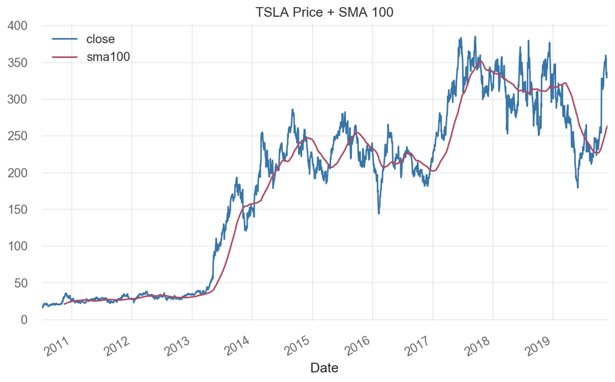

```python
df['sma100'] = df['close'].rolling(100).mean()
df[['close', 'sma100']].plot(title="TSLA Price + SMA 100")
```

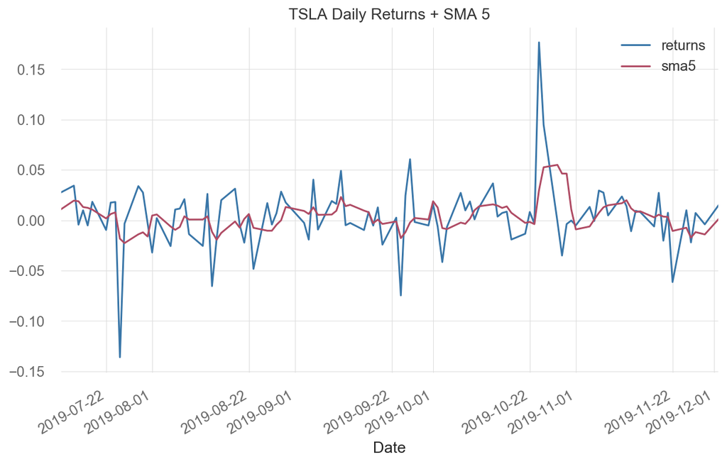

```python
df['sma5'] = df['returns'].rolling(5).mean()
df[['returns', 'sma5']][-100:].plot(title="TSLA Daily Returns + SMA 5")
```

[output not shown]

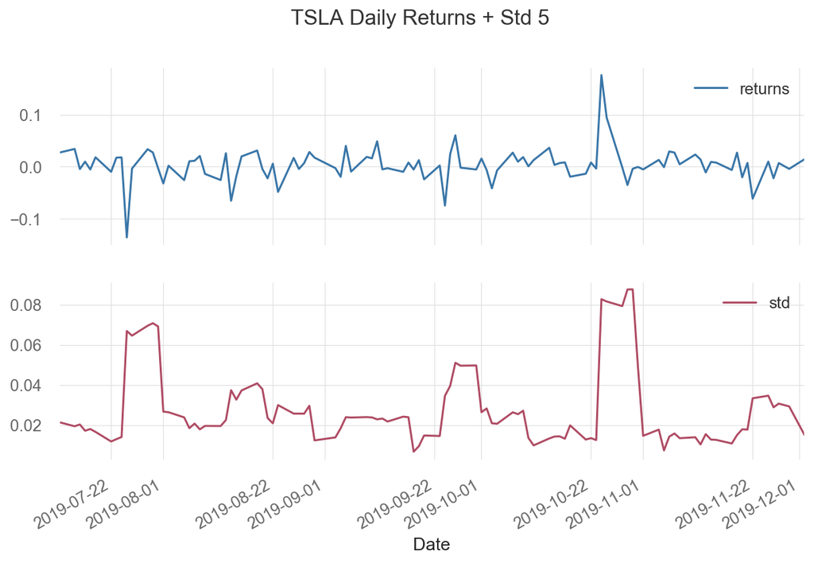

```python
df['std'] = df['returns'].rolling(5).std()

df[['returns', 'std']][-100:].plot(
    title="TSLA Daily Returns + Std 5", subplots=True)
```

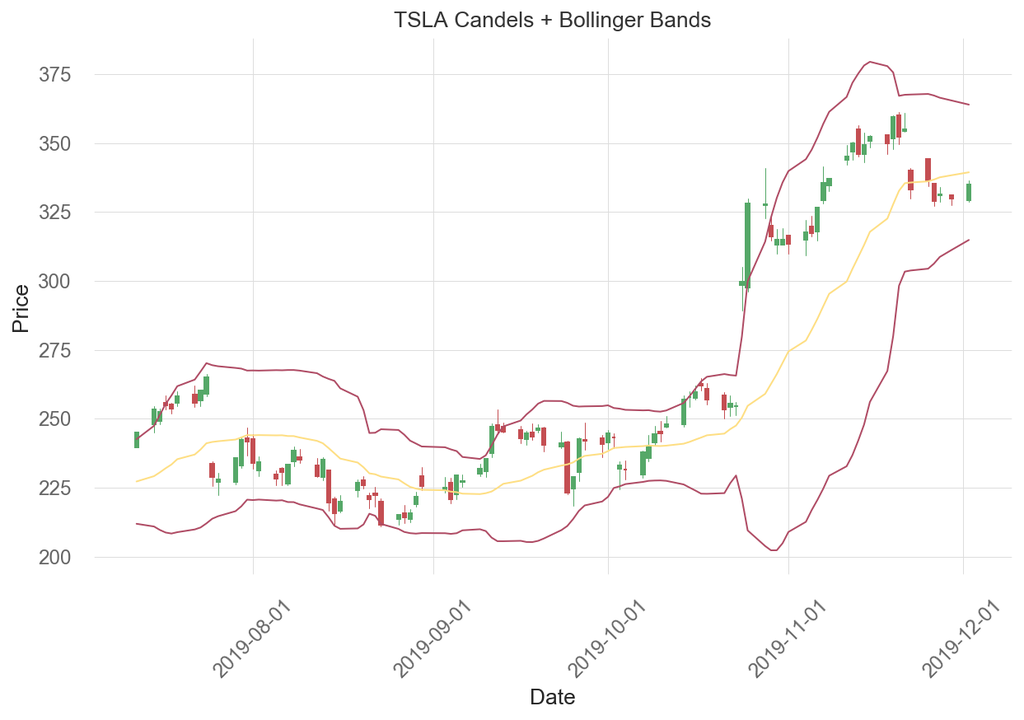

```python
# pure python bollinger bands
df['sma'] = df['close'].rolling(window=20).mean()
df['std'] = df['close'].rolling(window=20).std()

df['upperbb'] = df['sma'] + (df['std'] * 2)
df['lowerbb'] = df['sma'] - (df['std'] * 2)

ax = plot_candlestick(df[-100:])
ax.plot(df[-100:][['upperbb', 'lowerbb']], color="#af4b64", linewidth=1)
ax.plot(df[-100:][['sma']], color="#fede82", linewidth=1)
plt.title('TSLA Candels + Bollinger Bands')
plt.show()
```

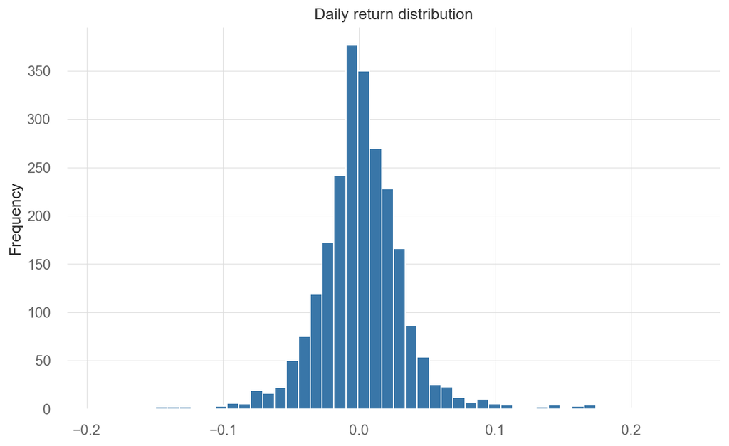

```python
df['returns'].plot.hist(bins=50, title="Daily return distribution")
```

```
[*********************100%***********************]  4 of 4 completed
```

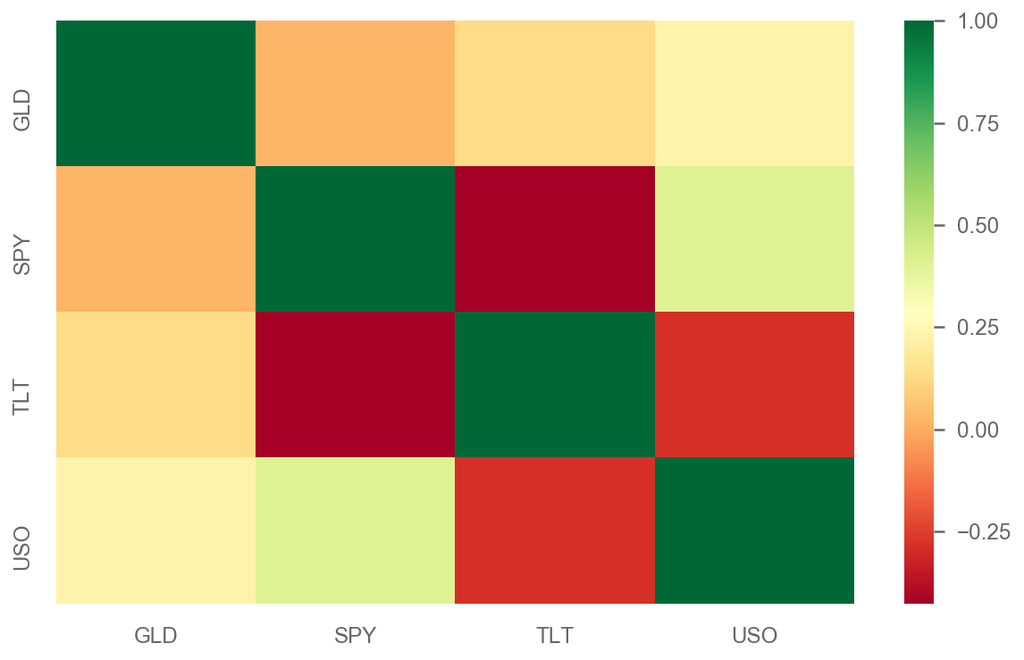

```python
basket = yf.download("GLD TLT SPY USO")['Adj Close'].pct_change().dropna()
sns.heatmap(basket.corr(), cmap="RdYlGn")
```

```python
df.describe()
```

|  | open | high | low | close | volume | returns | log_ret | volatility | sma100 | sma5 | std | sma | upperbb | lowerbb |
| --- | --- | --- | --- | --- | --- | --- | --- | --- | --- | --- | --- | --- | --- | --- |
| count | 2374.000000 | 2374.000000 | 2374.000000 | 2374.000000 | 2.374000e+03 | 2373.000000 | 2373.000000 | 2122.000000 | 2275.000000 | 2369.000000 | 2355.000000 | 2355.000000 | 2355.000000 | 2355.000000 |
| mean | 181.480299 | 184.620783 | 178.172713 | 181.496487 | 5.395288e+06 | 0.001637 | 0.001113 | 0.491208 | 182.776234 | 0.001692 | 8.908786 | 181.506671 | 199.324243 | 163.689099 |
| std | 113.465900 | 115.209477 | 111.610573 | 113.487016 | 4.706548e+06 | 0.032506 | 0.032319 | 0.099467 | 110.120620 | 0.014208 | 6.922657 | 112.489828 | 123.007040 | 102.764665 |
| min | 16.139999 | 16.629999 | 14.980000 | 15.800000 | 1.185000e+05 | -0.193274 | -0.214772 | 0.316833 | 20.987900 | -0.077369 | 0.332243 | 19.278000 | 20.823474 | 15.278575 |
| 25% | 34.050001 | 34.735001 | 33.452500 | 34.182500 | 1.827275e+06 | -0.014584 | -0.014692 | 0.397049 | 33.160050 | -0.006487 | 2.085381 | 34.163500 | 36.371567 | 31.867428 |
| 50% | 211.279999 | 215.115005 | 207.509995 | 210.945000 | 4.499900e+06 | 0.000708 | 0.000708 | 0.507521 | 214.903300 | 0.001545 | 8.287850 | 213.305499 | 233.364467 | 192.410784 |
| 75% | 262.362495 | 265.630013 | 257.955002 | 262.077492 | 7.199875e+06 | 0.017734 | 0.017579 | 0.569972 | 253.387000 | 0.009823 | 12.674337 | 263.089005 | 285.219144 | 239.450863 |
| max | 386.690002 | 389.609985 | 379.350006 | 385.000000 | 3.716390e+07 | 0.243951 | 0.218292 | 0.697556 | 351.352299 | 0.092223 | 36.927099 | 368.637997 | 408.489764 | 349.252567 |

```python
df['close'].resample('1W').ohlc().tail(10)
```

| Date | open | high | low | close |
| --- | --- | --- | --- | --- |
| 2019-10-06 | 240.869995 | 244.690002 | 231.429993 | 231.429993 |
| 2019-10-13 | 237.720001 | 247.889999 | 237.720001 | 247.889999 |
| 2019-10-20 | 256.959991 | 261.970001 | 256.950012 | 256.950012 |
| 2019-10-27 | 253.500000 | 328.130005 | 253.500000 | 328.130005 |
| 2019-11-03 | 327.709991 | 327.709991 | 313.309998 | 313.309998 |
| 2019-11-10 | 317.470001 | 337.140015 | 317.220001 | 337.140015 |
| 2019-11-17 | 345.089996 | 352.170013 | 345.089996 | 352.170013 |
| 2019-11-24 | 349.989990 | 359.519989 | 333.040009 | 333.040009 |
| 2019-12-01 | 336.339996 | 336.339996 | 328.920013 | 329.940002 |
| 2019-12-08 | 334.869995 | 334.869995 | 334.869995 | 334.869995 |

```python
df['close'].resample('3B').ohlc().tail(10)
```

| Date | open | high | low | close |
| --- | --- | --- | --- | --- |
| 2019-10-22 | 255.580002 | 299.679993 | 254.679993 | 299.679993 |
| 2019-10-25 | 328.130005 | 328.130005 | 316.220001 | 316.220001 |
| 2019-10-30 | 315.010010 | 315.010010 | 313.309998 | 313.309998 |
| 2019-11-04 | 317.470001 | 326.579987 | 317.220001 | 326.579987 |
| 2019-11-07 | 335.540009 | 345.089996 | 335.540009 | 345.089996 |
| 2019-11-12 | 349.929993 | 349.929993 | 346.109985 | 349.350006 |
| 2019-11-15 | 352.170013 | 359.519989 | 349.989990 | 359.519989 |
| 2019-11-20 | 352.220001 | 354.829987 | 333.040009 | 333.040009 |
| 2019-11-25 | 336.339996 | 336.339996 | 328.920013 | 331.290009 |
| 2019-11-28 | 329.940002 | 334.869995 | 329.940002 | 334.869995 |

# Trading Strategy Workflow

- Hypothesis
- Prototyping
- Backtesting
- Assessing performance
- Optimizing
- Going live

## Hypothesis

- Markets are mean-reverting
- After a big down day, smart buyers swoops in to buy at lower price

Our strategy:

```
BUY ON CLOSE when SPY drops 0.5% (or more)
SELL ON CLOSE of next day
```

## Prototyping / Quick (Vectorized) Backtesting

### Pros:

- Very fast - great for quickly testing ideas
- Requires much less coding compared to alternatives

### Cons:

- Danger of data snooping
- Usually cannot be used "as-is" for live trading

### Example:

```python
df = yf.download('SPY', start='2000-01-01', auto_adjust=True)
```

```
[*********************100%***********************]  1 of 1 completed
```

```python
%%time

df['SPY'] = df['Close'].pct_change()
df['Strategy'] = df[df['SPY'].shift(1) <= -0.005]['SPY']
```

```
CPU times: user 5.05 ms, sys: 929 µs, total: 5.98 ms
Wall time: 5.02 ms
```

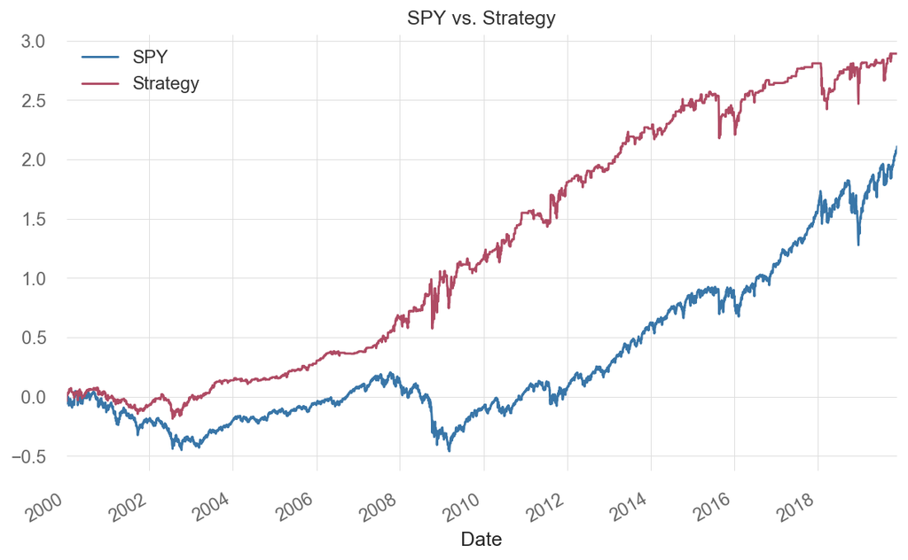

```python
df[['SPY', 'Strategy']].fillna(0).compsum().plot(title='SPY vs. Strategy')
```

## Event-Based Backtesting

**Once we've tested our hypothesis, it's time to use an event-based backtester to avoid look-ahead bias (among many other biases)**

### Pros:

- More reliable backtesting (no look-ahead bias)
- Code can be used "as-is" for live trading

### Cons:

- Takes longer to write and run your backtest

### Example:

```python
%%time
for ix, _ in df.iterrows():
    loc = df.index.get_loc(ix)
    if loc > 0:
        yday = (df.iloc[loc - 1] / df.iloc[loc - 2])['Close']
        if yday <= -0.005:
            df.loc[ix, "strategy"] = (df.iloc[loc] / df.iloc[loc - 1])['Close']
```

```
CPU times: user 2.58 s, sys: 7.4 ms, total: 2.58 s
Wall time: 2.59 s
```

# Assessing Performance

## Basic Performance Metrics

- **Sharpe Ratio** - risk adjusted return of investment
- **Max Drawdown** - max hole (and it's duration)
- **Recovery Factor** - how quickly the strategy recovers from drawdowns (net profit/max dd)
- **CAGR (Compound Annual Growth Rate)** - annualized % growth return
- **Profit Factor** - profit from winning trades / losses from losing trades
- **Win Rate** - % of trades with a net profit > 0
- **Yearly/Monthly/Quarterly/Daily/Hourly Breakdown** - seasonality discovery
- **Avg. Return per Trade**
- **Avg. Return from Winners/Losers per Trade**
- **Total Returns**

## Sharpe Ratio

`Sharpe(X) = (rX - Rf) / StdDev(X)`

#### Where:

- `X` is the investment
- `rX` is the average rate of the return of `X`
- `Rf` is the best available risk-free security (i.e. T-bills)
- `StdDev(X)` is the standard deviation of `rX`

```python
returns = df['Strategy']
sharpe = np.sqrt(252) * (np.mean(returns)) / np.std(returns)

sharpe
```

```
1.2516351270426027
```

```python
import quantstats as qs
```

```python
df[['SPY', 'Strategy']].sharpe()
```

```
SPY         0.391915
Strategy    0.610425
dtype: float64
```

```python
df[['SPY', 'Strategy']].max_drawdown()
```

```
SPY        -0.551894
Strategy   -0.243470
dtype: float64
```

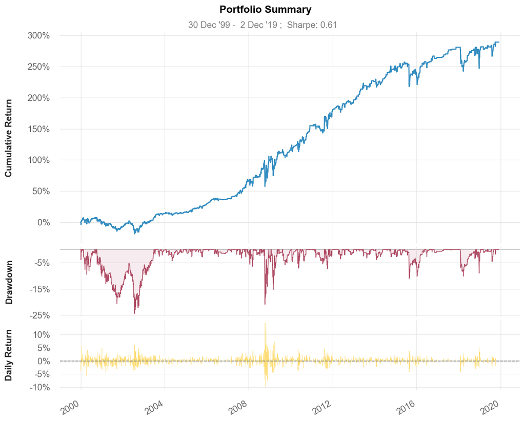

```python
qs.plots.snapshot(df['Strategy'])
```

```python
qs.reports.metrics(df['Strategy'], benchmark=df['SPY'], mode="full")
```

```
                           Strategy    Benchmark
-------------------------  ----------  -----------
Start Period               2000-01-03  2000-01-03
End Period                 2019-12-02  2019-12-02
Risk-Free Rate             0.0%        0.0%
Time in Market             24.0%       100.0%

Cumulative Return          289.23%     207.14%
CAGR%                      7.06%       5.79%
Sharpe                     0.61        0.39
Sortino                    0.94        0.56
Max Drawdown               -24.35%     -55.19%
Longest DD Days            1001        2404
Volatility (ann.)          12.46%      19.0%
R^2                        0.43        0.43
Calmar                     0.29        0.1
Skew                       1.75        0.16
Kurtosis                   54.09       11.48

Expected Daily %           0.03%       0.02%
Expected Monthly %         0.57%       0.47%
Expected Yearly %          7.03%       5.77%
Kelly Criterion            11.78%      7.86%
Risk of Ruin               0.0%        0.0%
Daily Value-at-Risk        -1.26%      -1.94%
Expected Shortfall (cVaR)  -2.34%      -2.34%

Payoff Ratio               0.98        0.98
Profit Factor              1.26        1.08
Common Sense Ratio         1.44        0.97
CPC Index                  0.7         0.57
Tail Ratio                 1.14        0.9
Outlier Win Ratio          18.61       3.98
Outlier Loss Ratio         2.59        3.38

MTD                        0.0%        -0.85%
3M                         2.18%       7.05%
6M                         1.76%       14.29%
YTD                        6.8%        26.44%
1Y                         3.12%       15.3%
```

[output cut: 11 more lines]

```

Avg. Drawdown              -2.73%      -1.98%
Avg. Drawdown Days         57          38
Recovery Factor            11.88       3.75
Ulcer Index                inf         1.02

Avg. Up Month              1.75%       3.24%
Avg. Down Month            -2.37%      -4.13%
Win Days %                 56.37%      54.43%
Win Month %                64.78%      62.5%
Win Quarter %              73.75%      70.0%
Win Year %                 80.0%       75.0%

Beta                       0.43        -
Alpha                      0.04        -
```

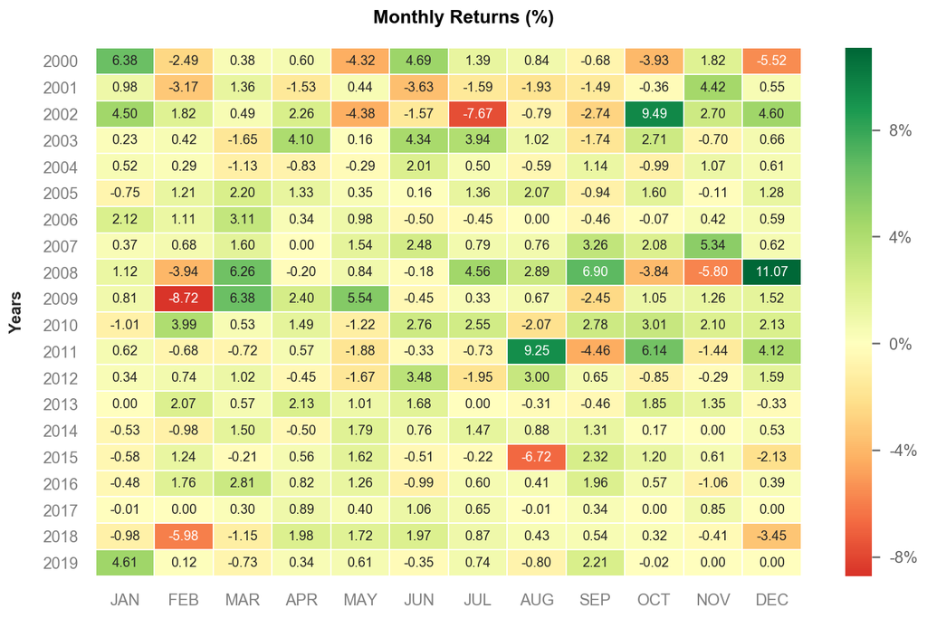

```python
qs.plots.monthly_heatmap(df['Strategy'])
```

# Optimizing

## The Strategy

- GO LONG where 50-day SMA >= 100-day SMA
- GO SHORT where 50-day SMA < 100-day SMA

## Visualize

```
[*********************100%***********************]  1 of 1 completed
```

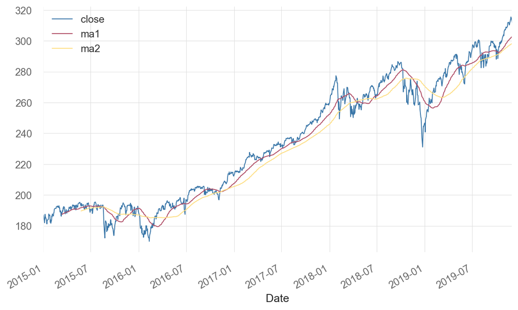

```python
df = yf.download('SPY', start='2015-01-01', auto_adjust=True)
df.columns = map(str.lower, df.columns)

df['ma1'] = df['close'].rolling(window=50).mean()
df['ma2'] = df['close'].rolling(window=100).mean()

df[['close', 'ma1', 'ma2']].plot(linewidth=1)
```

## Prototype

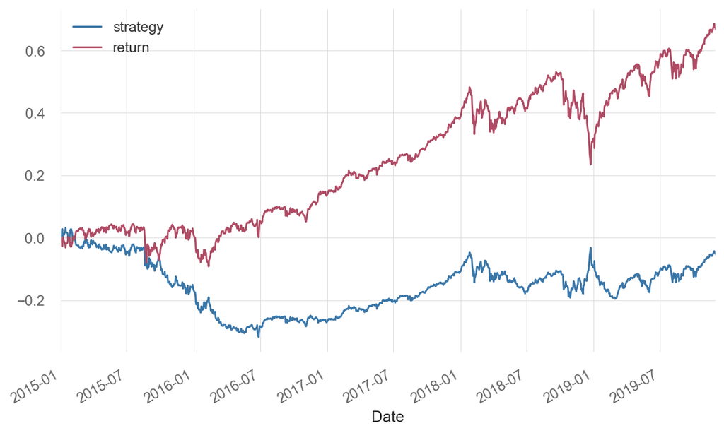

```python
df['return'] = df['close'].pct_change()

df['strategy'] = df['return'] * np.where(
    df['ma1'].shift(1) >= df['ma2'].shift(1), 1, -1)

df[['strategy', 'return']].compsum().plot()
```

## Let's parameterize this strategy...

```python
import numba

@numba.jit(forceobj=True)
def ma_strategy(prices, ma_fast, ma_slow):

    # create dataframe
    df = pd.DataFrame(data={"price": prices})

    # returns column
    df['return'] = df['price'].pct_change(1)

    # parameters
    df['ma1'] = df['price'].rolling(window=ma_fast).mean()
    df['ma2'] = df['price'].rolling(window=ma_slow).mean()

    # strategy
    df['strategy'] = df['return'] * np.where(
        df['ma1'].shift(1) >= df['ma2'].shift(1), 1, -1)

    return df['strategy'].fillna(0)
```

### Create moving average ranges

```python
ma1 = np.linspace(5, 50, 20).astype(int)
ma2 = np.linspace(100, 200, 21).astype(int)

print("MA1 =", ma1)
print("MA2 =", ma2)
```

```
MA1 = [ 5  7  9 12 14 16 19 21 23 26 28 31 33 35 38 40 42 45 47 50]
MA2 = [100 105 110 115 120 125 130 135 140 145 150 155 160 165 170 175 180 185
 190 195 200]
```

### Create metrics placeholder grids

```python
sharpes = np.zeros((len(ma1), len(ma2)))
returns = np.zeros(sharpes.shape)
drawdowns = np.zeros(sharpes.shape)
```

## Optimize

```python
# loop over ma1/ma2 combination and collect stats

train = df[:-250].copy()

for i1, ma1_val in enumerate(ma1):
    for i2, ma2_val in enumerate(ma2):
        pnl = ma_strategy(train['close'], ma1_val, ma2_val)

        sharpes[i1, i2] = pnl.sharpe()
        returns[i1, i2] = pnl.cagr()
        drawdowns[i1, i2] = pnl.max_drawdown()
```

### Results stored in `sharpes`, `returns` and `drawdowns`

```python
pd.DataFrame(sharpes).loc[:5, :5]
```

|  | 0 | 1 | 2 | 3 | 4 | 5 |
| --- | --- | --- | --- | --- | --- | --- |
| 0 | 0.020191 | -0.077605 | -0.000733 | -0.038161 | -0.155284 | 0.039494 |
| 1 | 0.014857 | -0.020451 | 0.064302 | -0.055821 | -0.001402 | -0.008455 |
| 2 | 0.045622 | -0.111062 | -0.080846 | -0.072848 | -0.242243 | -0.022134 |
| 3 | 0.017147 | -0.076420 | -0.195901 | -0.262545 | -0.359924 | 0.027871 |
| 4 | -0.273048 | -0.284678 | -0.111234 | -0.292124 | -0.358061 | -0.022014 |
| 5 | -0.343333 | -0.374049 | -0.270601 | -0.309994 | -0.349587 | -0.037495 |

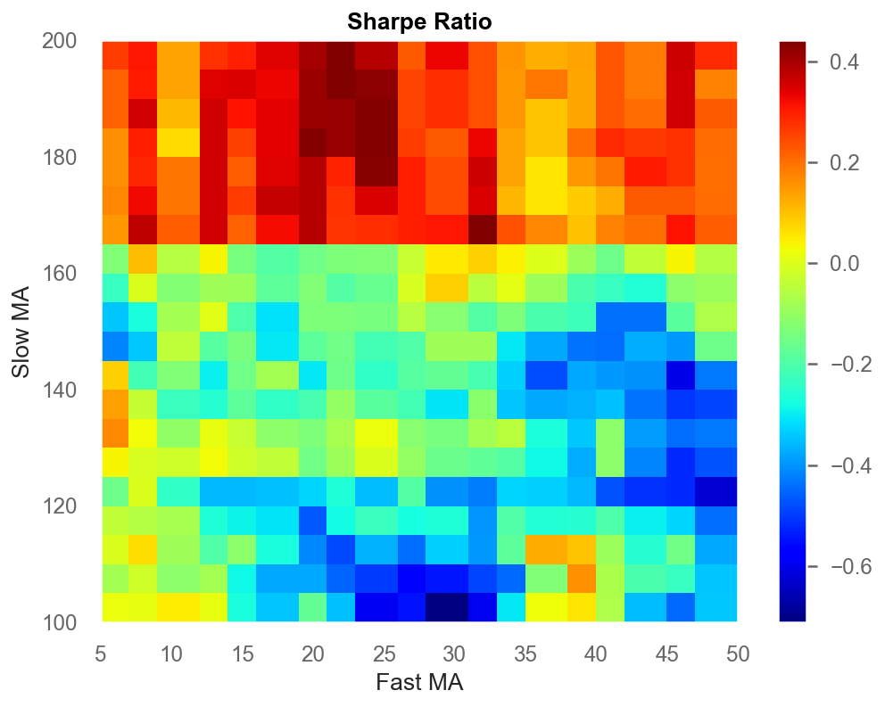

```python
fig, ax = plt.subplots(figsize=(8, 6))
plt.pcolormesh(ma1, ma2, sharpes.T, cmap="jet")
plt.title("Sharpe Ratio", fontweight="bold", color="black")
plt.xlabel("Fast MA")
plt.ylabel("Slow MA")
plt.colorbar()
```

## There's always simpler way :)

https://gist.github.com/ranaroussi/b87f45ca59f103128a01f7bc1372e00c

```python
from optimizeparams import optimize2d

opt = optimize2d(train['close'], ma_strategy,
                 param1=ma1, param2=ma2,
                 param1_name="Fast MA",
                 param2_name="Slow MA")


print(tabulate(pd.DataFrame(opt.reveal()),
               headers=['Metric', 'Sharpe', 'DD', 'CAGR', 'Volatility']))
```

```
Metric      Sharpe    DD    CAGR    Volatility
--------  --------  ----  ------  ------------
Fast MA         21     7      28             5
Slow MA        195   185     100           110
```

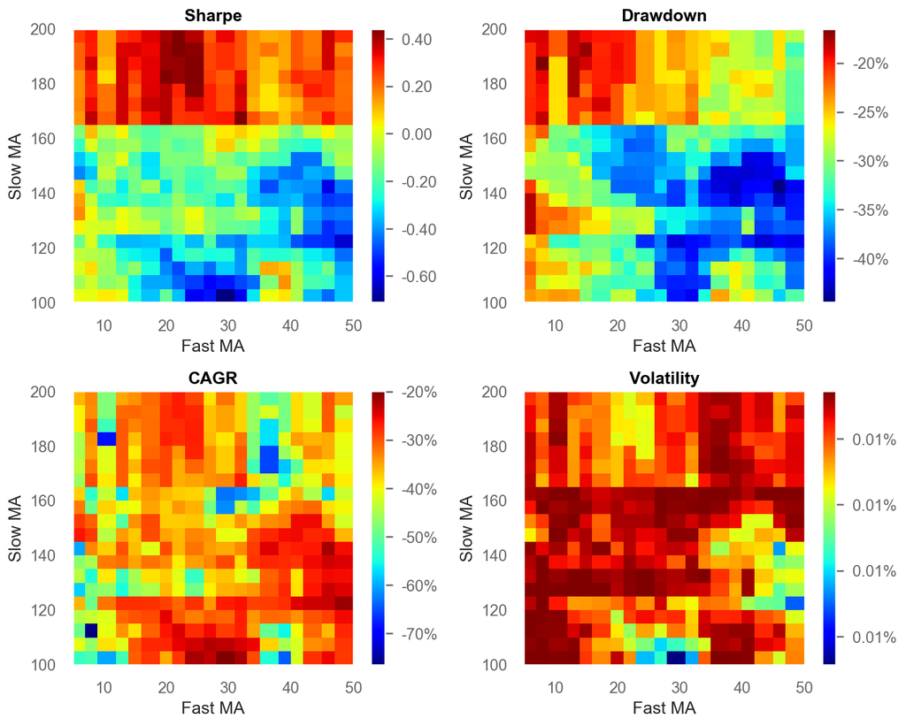

```python
opt.plot()
```

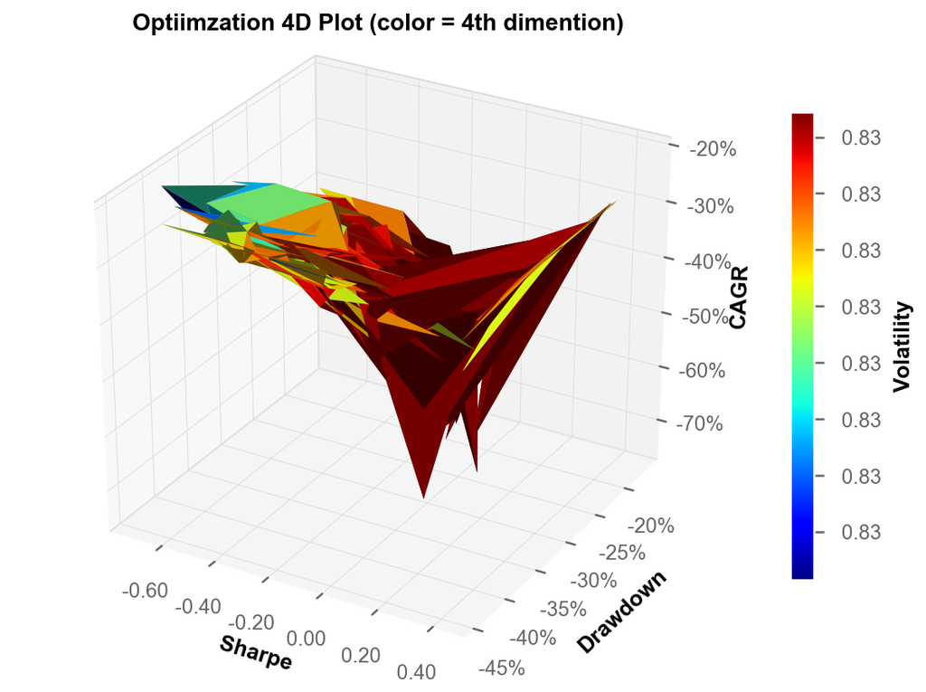

```python
opt.plot3d()
```

## Let's see the strategy using optimized params

```python
optimal = list(opt.reveal()['sharpe'].values())

train['strategy'] = ma_strategy(
    train['close'], optimal[0], optimal[1])

print("Using: %.f-day Fast MA and %.f-day Slow MA" % (
    optimal[0], optimal[1]))
```

```
Using: 21-day Fast MA and 195-day Slow MA
```

Performance Metrics

```
                    Strategy
------------------  ----------
Start Period        2014-12-31
End Period          2018-12-03
Risk-Free Rate      0.0%
Time in Market      100.0%

Cumulative Return   21.35%
CAGR%               5.05%
Sharpe              0.44
Sortino             0.61
Max Drawdown        -20.11%
Longest DD Days     688

Payoff Ratio        0.94
Profit Factor       1.08
Common Sense Ratio  1.01
CPC Index           0.55
Tail Ratio          0.93
Outlier Win Ratio   3.81
Outlier Loss Ratio  4.07

MTD                 -1.32%
3M                  -6.49%
6M                  -0.33%
YTD                 2.6%
1Y                  4.06%
3Y (ann.)           8.97%
5Y (ann.)           5.05%
10Y (ann.)          5.05%
All-time (ann.)     5.05%

Avg. Drawdown       -2.0%
Avg. Drawdown Days  43
Recovery Factor     1.06
Ulcer Index         1.02
```

Strategy Visualization

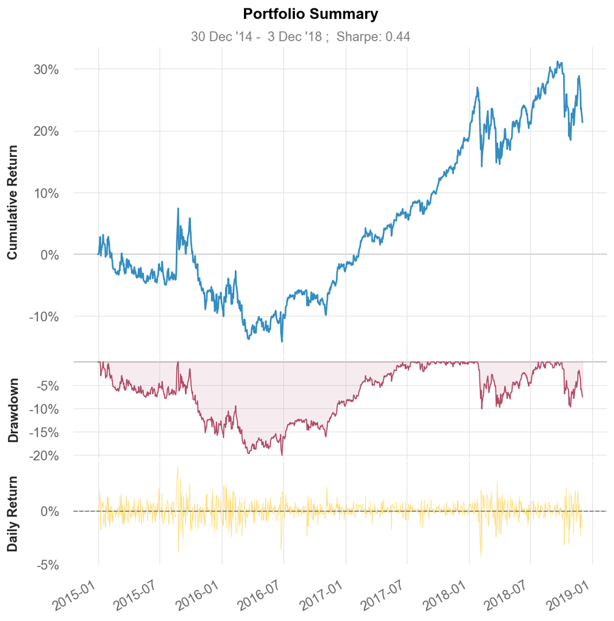

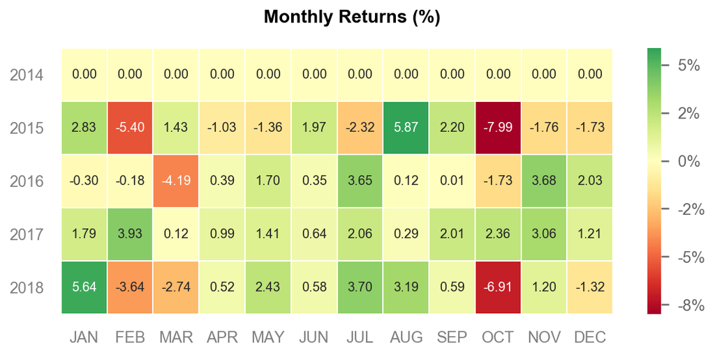

```python
qs.reports.basic(train['strategy'])
```

## Will it hold?

Performance Metrics

```
                    Strategy
------------------  ----------
Start Period        2014-12-31
End Period          2019-12-02
Risk-Free Rate      0.0%
Time in Market      100.0%

Cumulative Return   35.1%
CAGR%               6.3%
Sharpe              0.52
Sortino             0.72
Max Drawdown        -20.11%
Longest DD Days     688

Payoff Ratio        0.97
Profit Factor       1.1
Common Sense Ratio  1.08
CPC Index           0.57
Tail Ratio          0.98
Outlier Win Ratio   3.79
Outlier Loss Ratio  4.21

MTD                 -0.85%
3M                  7.05%
6M                  14.29%
YTD                 0.87%
1Y                  9.86%
3Y (ann.)           12.49%
5Y (ann.)           6.3%
10Y (ann.)          6.3%
All-time (ann.)     6.3%

Avg. Drawdown       -2.5%
Avg. Drawdown Days  53
Recovery Factor     1.75
Ulcer Index         1.02
```

Strategy Visualization

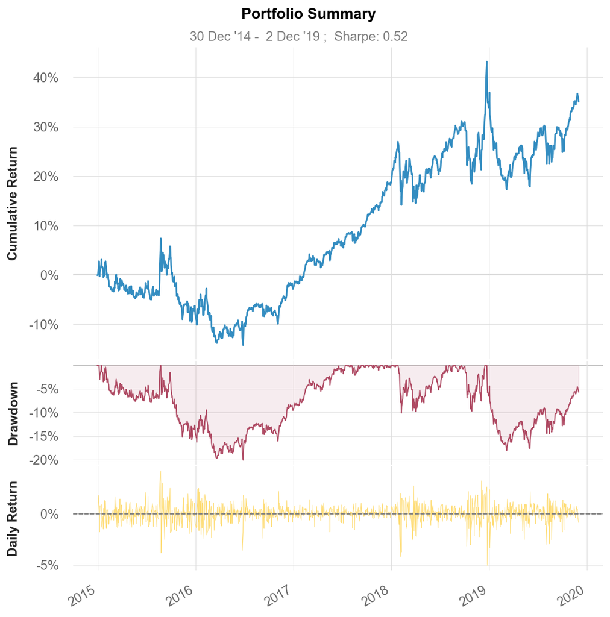

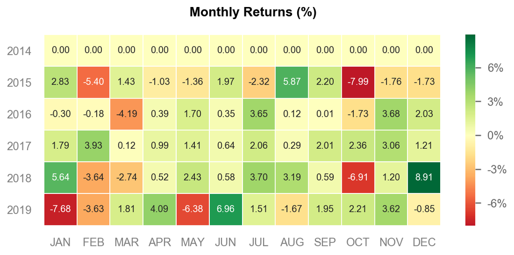

```python
test = df[-1500:].copy()
test['strategy'] = ma_strategy(test['close'], optimal[0], optimal[1])
qs.reports.basic(test['strategy'])
```

# To summerize...

### Python is a great language for data-science and trading 😁

# Python for Trading

### Thank you for your time!

**Ran Aroussi**  
Founder @ [Tradologics](http://tradologics.com)  
[@aroussi](http://twitter.com/aroussi) | aroussi.com | github.com/ranaroussi

© 2020. All rights reserved.